# TOP5 Severe Weather Events on Health and Ecomony between 1950 and 2011 in the United States

Wenqian_WANG

Friday, May 22, 2015

# Synopsis

Storms and other severe weather, resulting in fatalities, injuries, property and crop damage, can cause both public health and economic problems. In order to prevent such consequences, our project was carried out to analyse the impacts of these severe weather events in the United States between the years 1950 and 2011. The raw data of this project is based on the U.S. National Oceanic and Atmospheric Administration(NOAA)’s storm database, which tracks the characteristics of major storms and weather events in US. From these data, we find that tornado is the most harmful event for public health when looking into the sum of fatalities and injuries, while the other events, such as heat weave and tropical storm, can not be easily ignored. With respect to economic influence, flood is the main reason which leads to property and crop damage, and tornadoes, tstm wind, hail is equally important.

# Data Processing

## load the raw data

The raw data StormData.csv.bz2 is downloaded and extracted in the working directory by the following R commands. The head() function is also applied.

```r
setwd("D:/Coursera/ReproducibleResearch/Projet2/")
StormData <- read.csv("StormData.csv.bz2", sep=",", header=TRUE)
head(StormData)
```

```
##   STATE__           BGN_DATE BGN_TIME TIME_ZONE COUNTY COUNTYNAME STATE
## 1       1  4/18/1950 0:00:00     0130       CST     97     MOBILE    AL
## 2       1  4/18/1950 0:00:00     0145       CST      3    BALDWIN    AL
## 3       1  2/20/1951 0:00:00     1600       CST     57    FAYETTE    AL
## 4       1   6/8/1951 0:00:00     0900       CST     89    MADISON    AL
## 5       1 11/15/1951 0:00:00     1500       CST     43    CULLMAN    AL
## 6       1 11/15/1951 0:00:00     2000       CST     77 LAUDERDALE    AL
##    EVTYPE BGN_RANGE BGN_AZI BGN_LOCATI END_DATE END_TIME COUNTY_END
## 1 TORNADO         0                                               0
## 2 TORNADO         0                                               0
## 3 TORNADO         0                                               0
## 4 TORNADO         0                                               0
## 5 TORNADO         0                                               0
## 6 TORNADO         0                                               0
##   COUNTYENDN END_RANGE END_AZI END_LOCATI LENGTH WIDTH F MAG FATALITIES
```

[output cut: 20 more lines]

## Question 1 : which types of events are most harmful with respect to population health across the United States?

Two points have to be clarified in this parts:

1. what does “population health” stand for?

   With the help of head() function in the last section, we can figure out that *FATALITIES* and *INJURIES* are highly related with “HEALTH”. So we will take these two variables into consideration with the same coefficient (simple addition : *FATALITIES+INJURIES*).
2. which statistical methods will we take?

   We will look into not only the sum, but also the mean of *FATALITIES+INJURIES*, grouped by the variable *EVTYPE*.

### Sum of Fatalities and Injuries by Event Type

The top 10 most harmful events in aspect of total numbers are shown in the table below.

```r
sum_health <- aggregate(FATALITIES+INJURIES ~ EVTYPE, StormData, sum, na.rm=TRUE)
sum_health <- subset(sum_health, sum_health[,2]!=0)
colnames(sum_health) <- c("Event_Type", "Sum_Health_Damage")
sum_health <- sum_health[with(sum_health, order(-Sum_Health_Damage, Event_Type)),]
head(sum_health, 10)
```

```
##            Event_Type Sum_Health_Damage
## 834           TORNADO             96979
## 130    EXCESSIVE HEAT              8428
## 856         TSTM WIND              7461
## 170             FLOOD              7259
## 464         LIGHTNING              6046
## 275              HEAT              3037
## 153       FLASH FLOOD              2755
## 427         ICE STORM              2064
## 760 THUNDERSTORM WIND              1621
## 972      WINTER STORM              1527
```

The relevant plot is generated by ggplot2 package and stored in “p1”.

```r
library(ggplot2)
p1 <- ggplot(head(sum_health, 5), aes(x=Event_Type, y=Sum_Health_Damage)) +
geom_histogram(stat="identity", fill="steelblue") +
xlab("Event Type") +
theme(axis.text.x = element_text(angle = 20, hjust = 1)) +
ylab("Fatality and Injury") +
theme(axis.title = element_text(size = 12, face="bold", colour="steelblue")) +
ggtitle("Sum of Fatality and Injury (Top 5 Most Harmful Events)") +
theme(plot.title = element_text(size = 15, face="bold", colour="steelblue"), title = element_text(vjust=1))
```

### Mean of Fatalities and Injuries by Event Type

The top 10 most harmful events in aspect of mean are shown below.

```r
mean_health <- aggregate(FATALITIES+INJURIES ~ EVTYPE, StormData, mean, na.rm=TRUE)
mean_health <- subset(mean_health, mean_health[,2]!=0)
colnames(mean_health) <- c("Event_Type", "Mean_Health_Damage")
mean_health <- mean_health[with(mean_health, order(-Mean_Health_Damage, Event_Type)),]
head(mean_health, 10)
```

```
##                     Event_Type Mean_Health_Damage
## 277                  Heat Wave           70.00000
## 851      TROPICAL STORM GORDON           51.00000
## 954                 WILD FIRES           38.25000
## 821              THUNDERSTORMW           27.00000
## 842 TORNADOES, TSTM WIND, HAIL           25.00000
## 366         HIGH WIND AND SEAS           23.00000
## 279          HEAT WAVE DROUGHT           19.00000
## 656            SNOW/HIGH WINDS           18.00000
## 973    WINTER STORM HIGH WINDS           16.00000
## 411          HURRICANE/TYPHOON           15.21591
```

The relevant plot is generated by ggplot2 package and stored in “p2”.

```r
p2 <- ggplot(head(mean_health, 5), aes(x=Event_Type, y=Mean_Health_Damage)) +
geom_histogram(stat="identity", fill="steelblue") +
xlab("Event Type") +
theme(axis.text.x = element_text(angle = 20, hjust = 1)) +
ylab("Fatality and Injury") +
theme(axis.title = element_text(size = 12, face="bold", colour="steelblue")) +
ggtitle("Mean of Fatality and Injury (Top 5 Most Harmful Events)") +
theme(plot.title = element_text(size = 15, face="bold", colour="steelblue"), title = element_text(vjust=1))
```

## Results : Question 1

With “grid.arrange()” function in the package “gridExtra”, we are able to display two plots, p1 and p2, together.

```r
library("gridExtra")
```

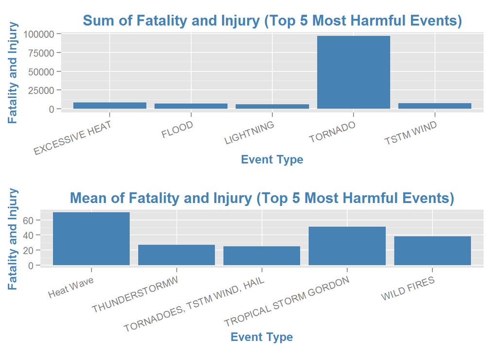

```r
grid.arrange(p1, p2)
```

In the plot above, we can see that tornado causes much more fatalities and injuries than other events between 1950 and 2011. However, when we look into the plot below, which stands for the mean of health damage, tornada itself is on longer present, while a similar “tornados, tstm wind, hail” appears. That is to say, the incidence of tornado is quite high in the United States, and his extent of health damage can not be underestimated.

Secondly, we can not ignore the events, whose means are higher than the others. For instance : “heat weave” has the highest mean of fatalities and injuries among all the events. That means : once it happens, the health damage that it brings could be very important.

## Question 2 : across the United States, which types of events have the greatest economic consequences?

Three points have to be clarified in this parts:

1. what does “economic consequences” stand for?

   With the help of head() function in the last section, we can figure out that *PROPDMG* and *CROPDMG* are highly related with “ECONOMY”. So we will take these two variables into consideration with the same coefficient (simple addition).
2. There are different symbols in the *PROPDMGEXP* and *CROPDMGEXP* columns which are unclear for calculation. What do they mean?

   According to the [documentation of National Weather Service](https://d396qusza40orc.cloudfront.net/repdata%2Fpeer2_doc%2Fpd01016005curr.pdf), alphabetical characters used to signify magnitude include “K” for thousands, “M” for millions, and “B” for billions. If additional precision is available, it may be provided in the narrative part of the entry. In this project, we only take alphabetical characters “K/M/B”, both upper and lower cases, into consideration. As to the exponential parameter, the base of 10 is applied.
3. which statistical methods will we take?

   Both sum and mean are calculated in this part.

### data preprocessing

To be more compact, we are going to use the subset of “StormData” data frame. The structure of “SubStormData” is shown at the end.

```r
SubStormData <- StormData[,c(8,25,26,27,28)]
#str(SubStormData)

#Exponential Transform function
expTransform <- function(x) {
    if(x=="B"||x=="b")  return(9)
    else if(x=="K"||x=="k")  return(3)
    else if(x=="M"||x=="m")  return(6)
    else return(0)
}

SubStormData$PROPDMGEXP <- sapply(SubStormData$PROPDMGEXP, expTransform)
SubStormData$CROPDMGEXP <- sapply(SubStormData$CROPDMGEXP, expTransform)
library(plyr)
SubStormData <- mutate(SubStormData, PROPDMG_CALCU=PROPDMG*(10^PROPDMGEXP))
SubStormData <- mutate(SubStormData, CROPDMG_CALCU=CROPDMG*(10^CROPDMGEXP))
str(SubStormData)
```

```
## 'data.frame':    902297 obs. of  7 variables:
##  $ EVTYPE       : Factor w/ 985 levels "   HIGH SURF ADVISORY",..: 834 834 834 834 834 834 834 834 834 834 ...
##  $ PROPDMG      : num  25 2.5 25 2.5 2.5 2.5 2.5 2.5 25 25 ...
##  $ PROPDMGEXP   : num  3 3 3 3 3 3 3 3 3 3 ...
##  $ CROPDMG      : num  0 0 0 0 0 0 0 0 0 0 ...
##  $ CROPDMGEXP   : num  0 0 0 0 0 0 0 0 0 0 ...
##  $ PROPDMG_CALCU: num  25000 2500 25000 2500 2500 2500 2500 2500 25000 25000 ...
##  $ CROPDMG_CALCU: num  0 0 0 0 0 0 0 0 0 0 ...
```

### Sum of Property and Crop Damage by Event Type

The top 5 most harmful events in aspect of total numbers are shown in the table below.

```r
sum_prop_dmg <- aggregate(PROPDMG_CALCU+CROPDMG_CALCU ~ EVTYPE, SubStormData, sum)
sum_prop_dmg <- subset(sum_prop_dmg, sum_prop_dmg[,2]!=0)
colnames(sum_prop_dmg) <- c("EVENT_TYPE", "SUM_PROP_CROP_DAMAGE")
sum_prop_dmg <- sum_prop_dmg[with(sum_prop_dmg, order(-SUM_PROP_CROP_DAMAGE, EVENT_TYPE)),]
head(sum_prop_dmg, 5)
```

```
##            EVENT_TYPE SUM_PROP_CROP_DAMAGE
## 170             FLOOD         150319678257
## 411 HURRICANE/TYPHOON          71913712800
## 834           TORNADO          57352114049
## 670       STORM SURGE          43323541000
## 244              HAIL          18758221521
```

The relevant plot is generated by ggplot2 package and stored in “p3”.

```r
p3 <- ggplot(head(sum_prop_dmg, 5), aes(x=EVENT_TYPE, y=SUM_PROP_CROP_DAMAGE)) +
geom_histogram(stat="identity", fill="steelblue") +
xlab("Event Type") +
theme(axis.text.x = element_text(angle = 20, hjust = 1)) +
ylab("Prop and Crop Damage") +
theme(axis.title = element_text(size = 12, face="bold", colour="steelblue")) +
ggtitle("Sum of Property and Crop Damage (Top 5 Most Harmful Events)") +
theme(plot.title = element_text(size = 15, face="bold", colour="steelblue"), title = element_text(vjust=1))
```

### Mean of Property and Crop Damage by Event Type

The top 5 most harmful events in aspect of mean are shown in the table below.

```r
mean_prop_dmg <- aggregate(PROPDMG_CALCU+CROPDMG_CALCU ~ EVTYPE, SubStormData, mean)
mean_prop_dmg <- subset(mean_prop_dmg, mean_prop_dmg[,2]!=0)
colnames(mean_prop_dmg) <- c("EVENT_TYPE", "MEAN_PROP_CROP_DAMAGE")
mean_prop_dmg <- mean_prop_dmg[with(mean_prop_dmg, order(-MEAN_PROP_CROP_DAMAGE, EVENT_TYPE)),]
head(mean_prop_dmg, 5)
```

```
##                     EVENT_TYPE MEAN_PROP_CROP_DAMAGE
## 842 TORNADOES, TSTM WIND, HAIL            1602500000
## 298  HEAVY RAIN/SEVERE WEATHER            1250000000
## 411          HURRICANE/TYPHOON             817201282
## 409             HURRICANE OPAL             354649556
## 670                STORM SURGE             165990579
```

The relevant plot is generated by ggplot2 package and stored in “p4”.

```r
p4 <- ggplot(head(mean_prop_dmg, 5), aes(x=EVENT_TYPE, y=MEAN_PROP_CROP_DAMAGE)) +
geom_histogram(stat="identity", fill="steelblue") +
xlab("Event Type") +
theme(axis.text.x = element_text(angle = 20, hjust = 1)) +
ylab("Prop and Crop Damage") +
theme(axis.title = element_text(size = 12, face="bold", colour="steelblue")) +
ggtitle("Mean of Property and Crop Damage (Top 5 Most Harmful Events)") +
theme(plot.title = element_text(size = 15, face="bold", colour="steelblue"), title = element_text(vjust=1))
```

## Results : Question 2

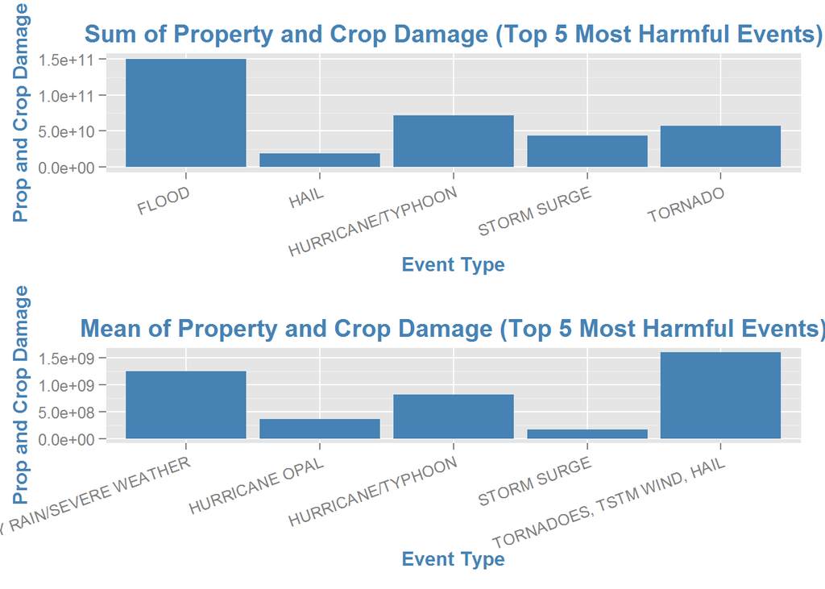

```r
library("gridExtra")
grid.arrange(p3, p4)
```

In the plot above, we can see that flood causes much more property and crop damages than other events between 1950 and 2011. When we look into the plot below, “tornados, tstm wind, hail” may be the most harmful event since his mean is not negligible. (only 100 times smaller than the total damage of flood).